# Statistical inference with the GSS data

## Clement LEFEVRE 10th April 2017.

### Load packages

```r
library(ggplot2)
library(dplyr)
library(tidyr)
library(statsr)
library(ggcorrplot)
library(gridExtra)
library(grid)

source('multiplot.r')
```

### Load data

```r
load("gss.Rdata")
```

## Part 1: Data

This dataset is a simplified sample of the official General Social Survey (GSS).

The [**GSS**](http://gss.norc.org/documents/codebook/GSS_Codebook_intro.pdf) is a survey focusing on US society, gathering informations related to **societal behaviors and attitudes**.

According to Wikpedia, “*It is one of the most influential studies in the social sciences, and is frequently referenced in leading publications, including The New York Times, The Wall Street Journal, and the Associated Press.*”

It has been used in 25,000 scholarly publications and every year by 400.000 students.

This study has been done for 40 years.

The data were gathered via face-to-face interviews by US households, for an average of 90 minutes.

#### Sampling methodology

**Random sampling** is implemented via strata : geographical area, sex, race, etc.

#### Case

Cases here are **adults living the US**.

#### Scope of inference

From the elements exposed (random sampling, no treatment assigned to random subjects), we can state that this is an **observational** study, from which we can extract **associations** and considere the model as **generalizable**, but no we cannot conclude on any **causality** between the explanatory variables (demographics and social) and the response (opinion, attitude).

## Part 2: Research question

As a french, two factors in the US society seem very specifics to me : the inherent racial dichotomy and the attitude towards guns.

Based on this dataset, i’d like to evaluate the possible **association** between **race** and **gun ownership**, and its **evolution** over years.

This short analysis will try to evaluate whether both are somehow related.

## Part 3: Exploratory data analysis

First, we can have a look at the distribution of interviewees’s race over the years :

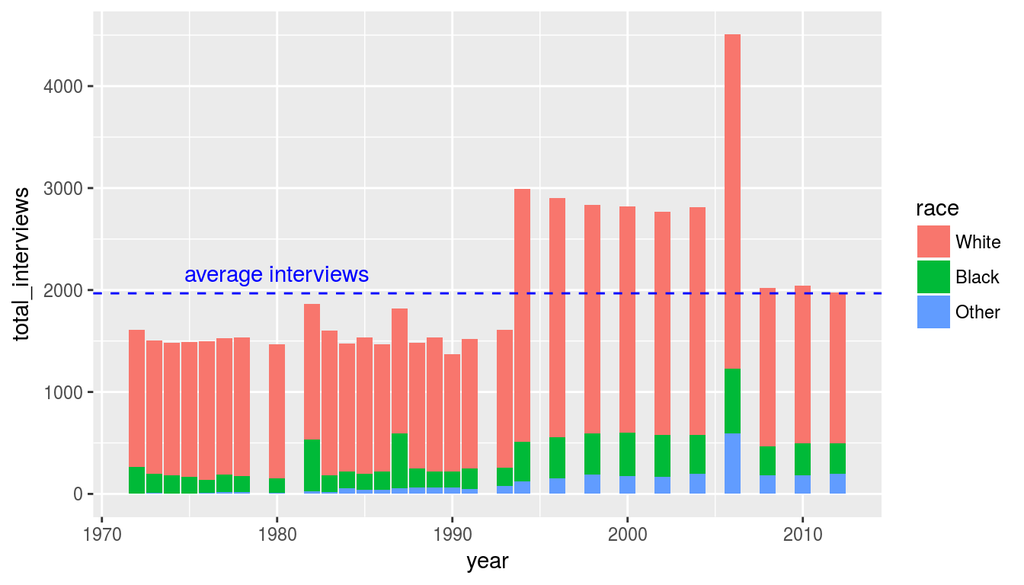

```r
group_per_year <- gss %>% group_by(year) %>% summarise(count=n())
average_interviews_per_year <-mean(group_per_year $count)

group_per_year <- gss %>% group_by(year,race) %>% summarise(total_interviews = n())
ggplot(data=group_per_year,aes(x=year,y=total_interviews,fill=race)) + geom_bar(stat='identity')+geom_hline(yintercept = mean(average_interviews_per_year),colour="blue", linetype="dashed")+annotate("text", x=1980, y=average_interviews_per_year*1.1, label="average interviews", color = "blue")
```

```r
summary(group_per_year)
```

```
##       year         race    total_interviews
##  Min.   :1972   White:29   Min.   :   4.0
##  1st Qu.:1980   Black:29   1st Qu.: 146.0
##  Median :1988   Other:29   Median : 204.0
##  Mean   :1989              Mean   : 655.9
##  3rd Qu.:1998              3rd Qu.:1306.0
##  Max.   :2012              Max.   :3284.0
```

Now we can focus on race and gun ownership. We first create a dataframe with the variables of interest and some additional ones :

- `year` : year of interview
- `age` : Age of respondent
- `sex` : Respondent’s sex
- `fear`: Afraid to walk at night in neighborhood
- `owngun` : Have gun in home
- `educ` : Highest year of school completed
- `coninc` : Total family income in constant dollars

```r
weapon_df <- gss %>% select(year,fear,owngun,sex,age,race,educ,coninc)
str(weapon_df)
```

```
## 'data.frame':    57061 obs. of  8 variables:
##  $ year  : int  1972 1972 1972 1972 1972 1972 1972 1972 1972 1972 ...
##  $ fear  : Factor w/ 2 levels "Yes","No": NA NA NA NA NA NA NA NA NA NA ...
##  $ owngun: Factor w/ 3 levels "Yes","No","Refused": NA NA NA NA NA NA NA NA NA NA ...
##  $ sex   : Factor w/ 2 levels "Male","Female": 2 1 2 2 2 1 1 1 2 2 ...
##  $ age   : int  23 70 48 27 61 26 28 27 21 30 ...
##  $ race  : Factor w/ 3 levels "White","Black",..: 1 1 1 1 1 1 1 1 2 2 ...
##  $ educ  : int  16 10 12 17 12 14 13 16 12 12 ...
##  $ coninc: int  25926 33333 33333 41667 69444 60185 50926 18519 3704 25926 ...
```

Let’s see for both variable the non-answered ratio :

```r
as.data.frame(colMeans(is.na(weapon_df))*100)
```

```
##        colMeans(is.na(weapon_df)) * 100
## year                          0.0000000
## fear                         39.8976534
## owngun                       39.6102417
## sex                           0.0000000
## age                           0.3540071
## race                          0.0000000
## educ                          0.2874117
## coninc                       10.2153835
```

From this table, we can say that even if 40% of interviewees did not provide an answer for `fear` and `owngun`, it seems, according to the sample size (57061 interviewees), somehow acceptable.

We can now remove the N/A from the dataframe :

```r
nrow(weapon_df)
```

```
## [1] 57061
```

```r
weapon_df<- weapon_df %>% na.omit()
nrow(weapon_df)
```

```
## [1] 30754
```

Now we can quickly see the Pearson correlation between those variables. First, we convert categorical variables into numerics values :

```r
weapon_df<- weapon_df %>% mutate(fear_num=ifelse(fear=='Yes',1,0))
weapon_df<- weapon_df %>% mutate(owngun_num=ifelse(owngun=='Yes',2,ifelse(owngun=='Refused',1,0)))

weapon_df<- weapon_df %>% mutate(sex_num=ifelse(sex=='Male',1,0))
weapon_df<- weapon_df %>% mutate(race_num=ifelse(race=='Black',0,ifelse(race=='White',2,1)))
```

Let’s plot a correlogramm :

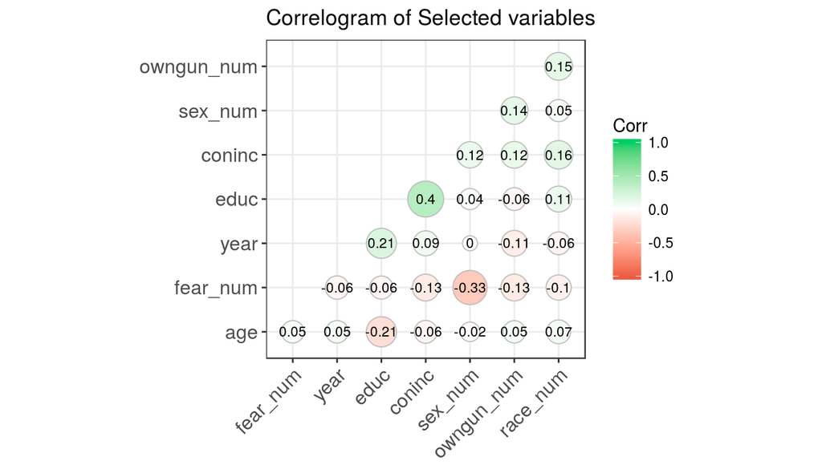

```r
weapon_df_numeric<- weapon_df %>% select(-c(fear,sex,race,owngun))

corr <- round(cor(weapon_df_numeric),3)
ggcorrplot(corr, hc.order = TRUE,
           type = "lower",
           lab = TRUE,
           lab_size = 3,
           method="circle",
           colors = c("tomato2", "white", "springgreen3"),
           title="Correlogram of Selected variables",
           ggtheme=theme_bw)
```

Well, some elements here :

- **education level** is strongly correlated to the **level of incomes**.(*not relevant for our question*)
- the **fear** factor is correlated to **gender** : men fear less walking in street at night.
- for **gun ownership**, the most correlated variables are in order :
  1. **race** (whites are more likely to own guns than Others and blacks, $\rho$ = 0.15),
  2. **sex** (men are more likely to own guns),
  3. **income** (the more income, the more frequent is gunownership).

Now we can prepare a dataframe with gun ownership grouped by year and race for both women and men :

```r
groupy_gun_race_male<- weapon_df %>% filter(sex=='Male') %>% group_by(year,race,owngun) %>% summarise(total=n(), median_age=median(age)) %>% mutate(ratio=total/sum(total)) %>% filter(owngun=='Yes')

groupy_gun_race_female<- weapon_df  %>% filter(sex=='Female')  %>% group_by(year,race,owngun) %>% summarise(total=n(), median_age=median(age)) %>% mutate(ratio=total/sum(total)) %>% filter(owngun=='Yes')
```

And we plot it :

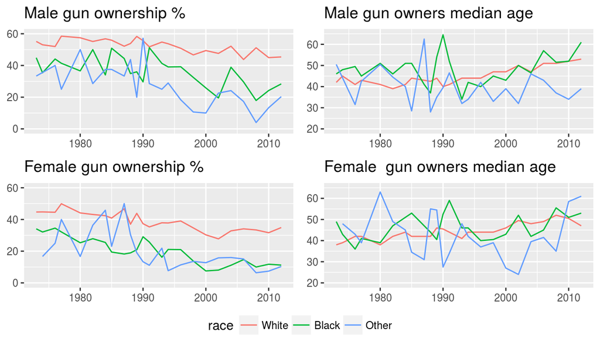

```r
p0<-ggplot(groupy_gun_race_male,aes(x=year,y=ratio*100,col=race)) + geom_line() + theme(axis.title.x=element_blank(),axis.title.y=element_blank()) +labs(title = "Male gun ownership %") +scale_y_continuous(limits = c(0, 60))

p1<-ggplot(groupy_gun_race_female,aes(x=year,y=ratio*100,col=race)) + geom_line() + theme(axis.title.x=element_blank(),axis.title.y=element_blank()) +labs(title = "Female gun ownership %")+scale_y_continuous(limits = c(0, 60))

p2<-ggplot(groupy_gun_race_male,aes(x=year,y=median_age,fill=race,color=race))+geom_line()+ theme(axis.title.x=element_blank(),axis.title.y=element_blank()) +labs(title = "Male gun owners median age")+scale_y_continuous(limits = c(20, 65))

p3<-ggplot(groupy_gun_race_female,aes(x=year,y=median_age,fill=race,color=race))+geom_line() + theme(axis.title.x=element_blank(),axis.title.y=element_blank()) +labs(title = "Female  gun owners median age")+scale_y_continuous(limits = c(20, 65))



grid_arrange_shared_legend(p0, p2, p1, p3)
```

A few comments :

- Overall gun ownership decreased over the year.
- Overall median age increased.
- Men of all races have higher gun ownership rate than women.
- The gap between whites and blacks gun ownership increased.

**Out of the current scope**, i’d like to see the incomes level relationship with gun ownership : Please take note that I remove the 0.5% of top incomes that i considere, maybe wrongly, as outliers.

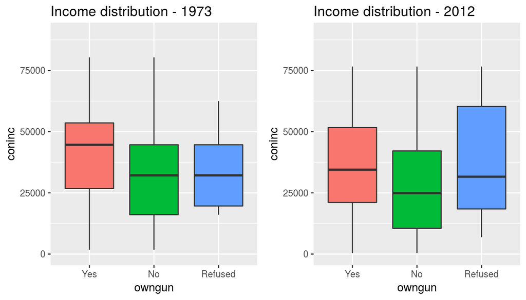

```r
p0<- ggplot(weapon_df%>% filter(year==1973)  %>% filter(coninc<quantile(coninc,.995)), aes(x=owngun, y=coninc,fill=owngun)) + geom_boxplot()+scale_y_continuous(limits = c(0, 90000))+ theme(legend.position="none") +labs(title= 'Income distribution - 1973')

p1<- ggplot(weapon_df%>% filter(year==2012)  %>% filter(coninc<quantile(coninc,.995)), aes(x=owngun, y=coninc,fill=owngun)) + geom_boxplot()+scale_y_continuous(limits = c(0, 90000))+ theme(legend.position="none")+labs(title = 'Income distribution - 2012')

multiplot(p0, p1,cols = 2)
```

We can clearly observe that during a 40 years time period, the gun ownership is still related to the income level. Rich households are more prone to won a gun, but compared to 1973, gun owners in 2012 are less wealthy.

In the next part, we will proceed to the simple hypothese testing, whether the mean income level amongst gun ownership categories is similar.

## Part 4: Inference

### Gun ownership rate evolution over time

Before we start testing the independance of gun ownership with race, we can as a starter check whether overall gun ownership did significantly changed over a period of 40 years.

We are in the context of one numerical variable (**gun ownership ratio**) and one categorical (i considere the **year** as category).

We can compute the corresponding proportions :

```r
ownership1973 <- weapon_df %>% filter(year==1973) %>%group_by(owngun)  %>% summarise(count=n())%>% mutate(ratio=count/sum(count), total = sum(count)) %>% filter(owngun=='Yes')
ownership1973
```

```
## # A tibble: 1 × 4
##   owngun count     ratio total
##   <fctr> <int>     <dbl> <int>
## 1    Yes   661 0.4817784  1372
```

```r
ownership2012 <- weapon_df %>% filter(year==2012) %>%group_by(owngun)  %>% summarise(count=n())%>% mutate(ratio=count/sum(count), total = sum(count))%>% filter(owngun=='Yes')
ownership2012
```

```
## # A tibble: 1 × 4
##   owngun count     ratio total
##   <fctr> <int>     <dbl> <int>
## 1    Yes   390 0.3403141  1146
```

Now we can compute the pooled proportion of gun owners :

```r
p_pool <- (661+390)/(1372+1146)
p_pool
```

```
## [1] 0.4173948
```

Let’s check the success failure conditions :

$n_{1973} \times \hat{p}_{pool} \ge 10$

$n_{2012} \times \hat{p}_{pool} \ge 10$

$(1-n_{2012}) \times \hat{p}_{pool} \ge 10$

```r
p_pool * 1372
```

```
## [1] 572.6656
```

```r
(1-p_pool)*1372
```

```
## [1] 799.3344
```

```r
p_pool * 1146
```

```
## [1] 478.3344
```

```r
(1-p_pool)*1146
```

```
## [1] 667.6656
```

So far, so good. We can compute the standard estimate SE :

$SE = \sqrt{\frac{\hat{p}_{pool}(1-\hat{p}_{pool})}{n_{1973}}+ \frac{\hat{p}_{pool}(1-\hat{p}_{pool})}{n_{2012}}}$

```r
SE<- sqrt(p_pool*(1-p_pool)/1372 + p_pool*(1-p_pool)/1146)
SE
```

```
## [1] 0.01973418
```

Now we can compute the p_value :

```r
Z<- (0.3403141-0.4817784)/SE
Z
```

```
## [1] -7.16849
```

```r
2*pnorm(Z)
```

```
## [1] 7.582962e-13
```

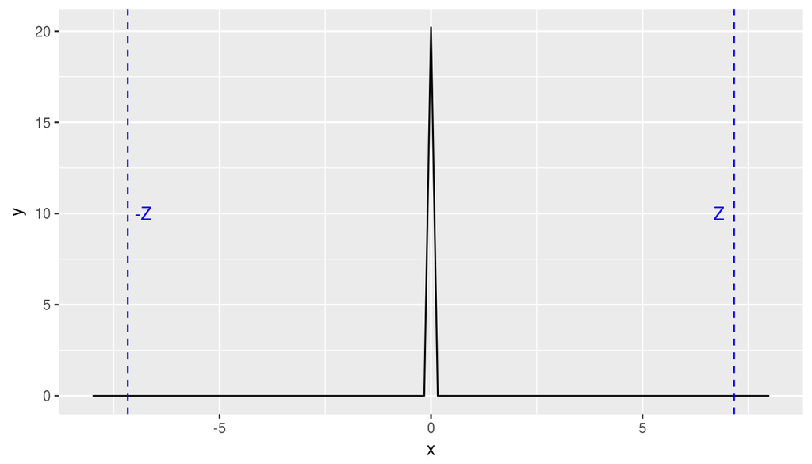

```r
ggplot(data.frame(x = c(-8, 8)), aes(x)) +
  stat_function(fun = dnorm, args = list(mean = 0, sd = SE)) + geom_vline(xintercept = Z,,col='blue',linetype="dashed")+geom_vline(xintercept = -Z,col='blue',linetype="dashed")  +annotate("text", x=-Z*.95, y=10, label="Z", color = "blue")  +annotate("text", x=Z*.95, y=10, label="-Z", color = "blue")
```

From the Z value, it is obvious that the probability that the gun ownership rate in 2012 is different than the one in 1973 occurs by chance is almost zero. This has been confirmed by the chart above.

This conclusion is confirmed by the following article from the Wapo : [**“ownership fall”**](https://www.washingtonpost.com/news/wonk/wp/2016/06/29/american-gun-ownership-is-now-at-a-30-year-low/?utm_term=.f4605793b86f)

### Gun Ownership amongst races and over time

Now, we can test the independance of the gun ownership rate from the race :

#### Hypotheses

$H_{0}:$ Race and gun ownership are independent.

$H_{A}:$ Race and gun ownership are dependent.

#### Chi-square test of independance

We want to test the independance of gun ownership (‘Yes’,‘No’) with race (‘White’, ‘Black’,‘Other’). *Nota Bene :* I removed the “Refusal” category from the sample, as it does not provide evidence of the ownership or not.

We are in the case of two categorical variables, with at least 1 with more than 2 levels, the only testing method i see here is the $\chi^2$ test.

##### Conditions for the chi-square test:

1. Independence: Sampled observations must be independent.

   ‣ random sample/assignment ✔ *Checked*

   ‣ if sampling without replacement, n < 10% of population ✔ *Checked*

   ‣ each case only contributes to one cell in the table ✔ *Checked*
2. Sample size: Each particular scenario (i.e. cell) must have at least 5 expected cases. ✔ *Checked*

I’ll use the R function *chisq.test*, but first the appropriate table ownership/race :

```r
gun_race <-weapon_df %>% filter(year==2012)  %>% filter(owngun=='Yes' | owngun=='No',owngun!='Refused')

gun_race <- droplevels(gun_race)
gun_race <- table(gun_race$owngun,gun_race$race)
gun_race
```

```
##
##       White Black Other
##   Yes   340    32    18
##   No    505   138    99
```

```r
chisq.test(gun_race)
```

```
##
##  Pearson's Chi-squared test
##
## data:  gun_race
## X-squared = 49.744, df = 2, p-value = 1.578e-11
```

For the year 2012, we reject the $H_{0}$ : Race and gun ownership are not independant.

What could be interesting is to see the evolution of this p_value over the years :

We can write a generic function to compute the corresponding p.value :

```r
chi2_independance_pvalue<- function(df,year_){
gun_race <-df %>% filter(year==year_)  %>% filter(owngun=='Yes' | owngun=='No')

gun_race <- droplevels(gun_race)
gun_race <- table(gun_race$owngun,gun_race$race)

chi2<- chisq.test(gun_race)

return(chi2$p.value)
}
```

Let’s compute the evolution of this p.value along the years :

```r
gun_asked<-gss %>% group_by(year,owngun) %>% filter(!is.na(owngun))
year_asked<-unique(gun_asked$year)
```

```r
# My deep apologies, i could not write a cleaner way to create a dataframe from a loop.
x<-list()
for (year in year_asked){
 chi2 <-  chi2_independance_pvalue(weapon_df,year)
 x[as.character(year)]<-list('pvalue'=chi2)
}
```

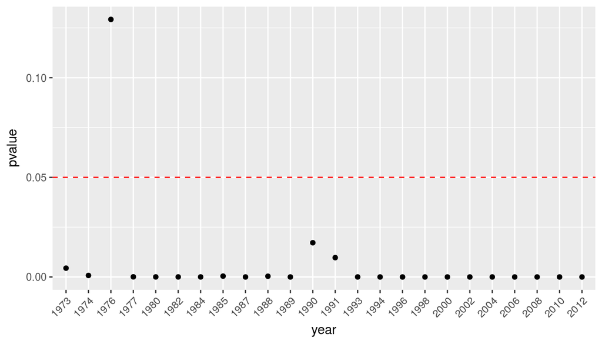

```r
df_pvalues<-as.data.frame(x) %>% gather()

colnames(df_pvalues)<-c('yearX','pvalue')
df_pvalues<- df_pvalues %>% separate(yearX,into = c("X", "year"), sep = "X")

ggplot(df_pvalues ,aes(x=year,y=pvalue)) + geom_point()+ theme(axis.text.x=element_text(angle=45, hjust=1)) +geom_hline(yintercept = .05,col='red',linetype="dashed")
```

The pvalue, with the exception of the year 1976, are all far below 0.05.

We might exclude this 1976 point as an outliers, and plot the log of the pvalue :

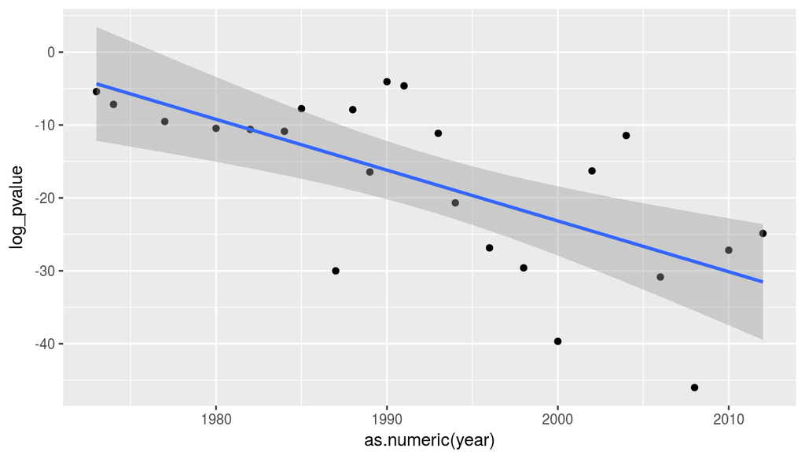

```r
df_pvalues$log_pvalue<-log(df_pvalues$pvalue)

ggplot(data=df_pvalues %>% filter(pvalue<.1),aes(x=as.numeric(year),y=log_pvalue)) + geom_point() +
  geom_smooth(method='lm')
```

What we observe here is a decreasing trend towards zero for the p-value. I would conclude that over the 40 years, the chance of rejection of the hypothese of independance between gun ownership and race has got stronger.

### Mean income equality test amongst gun ownership response (*out of scope*)

#### Hypotheses

$H_{0}:$ The average income level is the same across all gun ownership categories.

$H_{A}:$ The average income level differs between at least one pair of gun ownership category.

#### ANOVA (*bites the dust*)

In this last test, i would like to implement an Analyse of variance (ANOVA) for the mean income for different categories of gun ownership response (‘Yes’,‘No’, ‘Refusal’).

As seen in the EDA part, for 1973 and 2012, we noticed a gap for the **median** income amonst the gun owners and the others.

Can we prove the **mean** also differ via an Anova test ?

I first compute a linear model for both years :

```r
lm.1973 <- lm(coninc ~ owngun, data=weapon_df %>% filter(year==1973))
lm.2012 <- lm(coninc ~ owngun, data=weapon_df %>% filter(year==2012))

summary(lm.1973)
```

```
##
## Call:
## lm(formula = coninc ~ owngun, data = weapon_df %>% filter(year ==
##     1973))
##
## Residuals:
##    Min     1Q Median     3Q    Max
## -44122 -21533  -1265  16592  70546
##
## Coefficients:
##               Estimate Std. Error t value Pr(>|t|)
## (Intercept)      45908       1050  43.744  < 2e-16 ***
## owngunNo         -8304       1464  -5.673 1.71e-08 ***
## owngunRefused    -5496       7859  -0.699    0.484
## ---
## Signif. codes:  0 '***' 0.001 '**' 0.01 '*' 0.05 '.' 0.1 ' ' 1
##
## Residual standard error: 26980 on 1369 degrees of freedom
## Multiple R-squared:  0.02298,    Adjusted R-squared:  0.02156
## F-statistic:  16.1 on 2 and 1369 DF,  p-value: 1.224e-07
```

```r
summary(lm.2012)
```

```
##
## Call:
## lm(formula = coninc ~ owngun, data = weapon_df %>% filter(year ==
##     2012))
##
## Residuals:
##    Min     1Q Median     3Q    Max
## -56382 -31870 -14635  17566 133083
##
## Coefficients:
##               Estimate Std. Error t value Pr(>|t|)
## (Intercept)      56765       2376  23.892  < 2e-16 ***
## owngunNo        -11136       2935  -3.795 0.000156 ***
## owngunRefused   -17630      12763  -1.381 0.167444
## ---
## Signif. codes:  0 '***' 0.001 '**' 0.01 '*' 0.05 '.' 0.1 ' ' 1
##
## Residual standard error: 46920 on 1143 degrees of freedom
## Multiple R-squared:  0.01301,    Adjusted R-squared:  0.01129
## F-statistic: 7.535 on 2 and 1143 DF,  p-value: 0.0005613
```

Now we can compute the F statistic and the corresponding p_value :

```r
anova(lm.1973)
```

```
## Analysis of Variance Table
##
## Response: coninc
##             Df     Sum Sq    Mean Sq F value    Pr(>F)
## owngun       2 2.3445e+10 1.1723e+10  16.102 1.224e-07 ***
## Residuals 1369 9.9664e+11 7.2800e+08
## ---
## Signif. codes:  0 '***' 0.001 '**' 0.01 '*' 0.05 '.' 0.1 ' ' 1
```

```r
anova(lm.2012)
```

```
## Analysis of Variance Table
##
## Response: coninc
##             Df     Sum Sq    Mean Sq F value    Pr(>F)
## owngun       2 3.3176e+10 1.6588e+10  7.5346 0.0005613 ***
## Residuals 1143 2.5164e+12 2.2016e+09
## ---
## Signif. codes:  0 '***' 0.001 '**' 0.01 '*' 0.05 '.' 0.1 ' ' 1
```

For both years, the p_value for the F statistic is well below the significant level, we can reject the null hypothese. The mean income discrepancies amongst gun ownership categories **do not happen by chance**.